# Assignment10

Gcy

By *Changyu Gao*, PB15121717

## 10.12

```r
r11 <- matrix(c(1, .8, .8, 1), nrow = 2)
r21 <- matrix(c(.26, .67, .34,
                .33, .59, .34), nrow = 3)
r12 <- t(r21)
r22 <- diag(rep.int(1, 3))
r22[lower.tri(r22)] <- r22[upper.tri(r22)] <- c(.37, .21, .35)
r1 <- rbind(cbind(r11, r12), cbind(r21, r22))
r1
```

```
##      [,1] [,2] [,3] [,4] [,5]
## [1,] 1.00 0.80 0.26 0.67 0.34
## [2,] 0.80 1.00 0.33 0.59 0.34
## [3,] 0.26 0.33 1.00 0.37 0.21
## [4,] 0.67 0.59 0.37 1.00 0.35
## [5,] 0.34 0.34 0.21 0.35 1.00
```

```r
# simple matrix power using spectrum decomposition
matrix_power <- function(A, p) {
  eig <- eigen(A)
  V <- eig$vectors
  L <- eig$values
  V %*% diag(L ^ p) %*% t(V)
}

p <- 2; q <- 3; n <- 70
r11sqrt <- matrix_power(r11, -1/2)
r22sqrt <- matrix_power(r22, -1/2)
A <- r11sqrt %*% r12 %*% solve(r22, r21) %*% r11sqrt
B <- r22sqrt %*% r21 %*% solve(r11, r12) %*% r22sqrt
eigA <- eigen(A)
eigB <- eigen(B)
cat("Sample canonical correlations:")
```

```
## Sample canonical correlations:
```

```r
sqrt(eigA$values)
```

```
## [1] 0.6879479 0.1868654
```

```r
cat("First canonical pair:")
```

```
## First canonical pair:
```

```r
eigA$vectors[, 1] %*% r11sqrt # U_1
```

```
##            [,1]       [,2]
## [1,] -0.7689274 -0.2720729
```

```r
eigB$vectors[, 1] %*% r22sqrt # V_1
```

```
##             [,1]       [,2]       [,3]
## [1,] -0.04912716 -0.8975114 -0.1900411
```

```r
# tesing
stat <- -(n-1-(p+q+1)/2) * log(prod(1 - eigA$values))
stat
```

```
## [1] 44.65657
```

```r
alpha <- .05
crit <- qchisq(1-alpha, p*q)
stat > crit # reject H0 if this is true
```

```
## [1] TRUE
```

```r
stat1 <- -(n-1-(p+q+1)/2) * log(1 - eigA$values[2])
stat1 > crit # reject H0^(1) if this is true
```

```
## [1] FALSE
```

a), b) Sample canonical correlations and first canonical pairs are shown above.

In the testing, we reject $H_0$ at the $\alpha=.05$ level but do not reject $H_0^{(1)}: \rho_1^* \ne 0, \rho_2^* = 0$.

## 10.13

```r
r2 <- as.matrix(read.table("10-13.txt"))
r11 <- r2[1:5, 1:5]
r21 <- r2[6:9, 1:5]
r12 <- t(r21)
r22 <- r2[6:9, 6:9]

p <- 5; q <- 4; n <- 138
r11sqrt <- matrix_power(r11, -1/2)
r22sqrt <- matrix_power(r22, -1/2)
A <- r11sqrt %*% r12 %*% solve(r22, r21) %*% r11sqrt
B <- r22sqrt %*% r21 %*% solve(r11, r12) %*% r22sqrt
eigA <- eigen(A)
eigB <- eigen(B)
cat("Sample canonical correlations:")
```

```
## Sample canonical correlations:
```

```r
sqrt(eigA$values[1:4])
```

```
## [1] 0.90922751 0.63636707 0.25587226 0.09388131
```

```r
# tesing
stat <- -(n-1-(p+q+1)/2) * log(prod(1 - eigA$values))
stat
```

```
## [1] 309.9884
```

```r
alpha <- .01
crit <- qchisq(1-alpha, p*q)
stat > crit # reject H0 if this is true
```

```
## [1] TRUE
```

```r
stat1 <- -(n-1-(p+q+1)/2) * log(prod(1 - eigA$values[-1]))
stat1 > crit # reject H0^(1) if this is true
```

```
## [1] TRUE
```

```r
stat2 <- -(n-1-(p+q+1)/2) * log(prod(1 - eigA$values[c(-1, -2)]))
stat2 > crit # reject H0^(2) if this is true
```

```
## [1] FALSE
```

```r
eigA$vectors[, 1] %*% r11sqrt # U_1
```

```
##            [,1]       [,2]      [,3]      [,4]       [,5]
## [1,] -0.2146135 -0.1719493 0.3296717 0.2638233 -0.2975785
```

```r
eigB$vectors[, 1] %*% r22sqrt # V_1
```

```
##           [,1]      [,2]       [,3]        [,4]
## [1,] 0.5350075 0.2876792 -0.4569024 -0.02504258
```

```r
eigA$vectors[, 2] %*% r11sqrt # U_2
```

```
##            [,1]     [,2]      [,3]       [,4]       [,5]
## [1,] -0.9232216 0.584833 -0.652574 -0.3414901 -0.5507805
```

```r
eigB$vectors[, 2] %*% r22sqrt # V_2
```

```
##          [,1]       [,2]      [,3]       [,4]
## [1,] 1.010247 0.02743025 0.9782179 -0.1796329
```

```r
Az_inv <- solve(t(eigA$vectors[]) %*% r11sqrt)
v1 <- Az_inv[,1]
sum(diag(v1 %o% v1)) / p # proportion explained
```

```
## [1] 0.6292283
```

```r
Bz_inv <- solve(t(eigB$vectors[]) %*% r22sqrt)
v2 <- Bz_inv[,1]
sum(diag(v2 %o% v2)) / q # proportion explained
```

```
## [1] 0.4496485
```

1. At the $\alpha = .01$ level, we reject $H_0,H_0^(1)$ but do not reject $H_0^(2): \rho_1^* \ne 0, \rho_2^* \ne 0, \rho_3^* = 0,\rho_4^* = 0$

Significant sample canonical variates are shown above.

2. Yes. $\hat U_1$ contrasts “damaged kernels”, “foreign material” with other quality figures. $\hat V_1$ combines those quality figures.
3. We compute that the proportion explained is 62.9% and 45.0% respectively.

## 11.23

```r
X <- read.table("T1-6.DAT")
head(X)
```

```
##   V1    V2  V3    V4  V5 V6
## 1 18 152.0 1.6 198.4 0.0  0
## 2 19 138.0 0.4 180.8 1.6  0
## 3 20 144.0 0.0 186.4 0.8  0
## 4 20 143.6 3.2 194.8 0.0  0
## 5 20 148.8 0.0 217.6 0.0  0
## 6 21 141.6 0.8 181.6 0.8  0
```

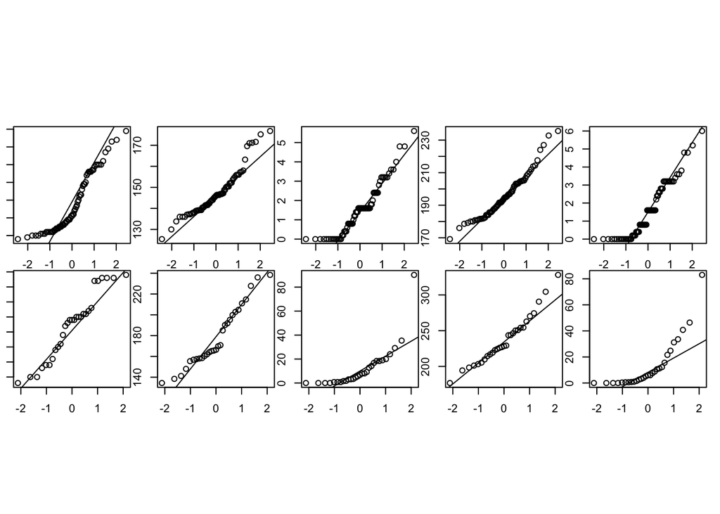

```r
splitX <- split(X[,-6], X$V6)
nonmult <- splitX[[1]]
mult <- splitX[[2]]
n1 <- nrow(nonmult)
n2 <- nrow(mult)
plotqq <- function(col, title="") {
  qqp <- qqnorm(col, main = title)
  qqline(col)
  with(qqp, cor(x, y))
}
layout(matrix(1:10, nrow = 2, byrow = TRUE), respect = TRUE)
par(mar=rep.int(1,4))
nonmult.rqs <-  sapply(nonmult, plotqq)
mult.rqs <-  sapply(mult, plotqq)
```

```r
nonmult.rqs
```

```
##        V1        V2        V3        V4        V5
## 0.9448159 0.9613327 0.9558495 0.9757393 0.9444650
```

```r
mult.rqs
```

```
##        V1        V2        V3        V4        V5
## 0.9713740 0.9702901 0.7952278 0.9786859 0.8413500
```

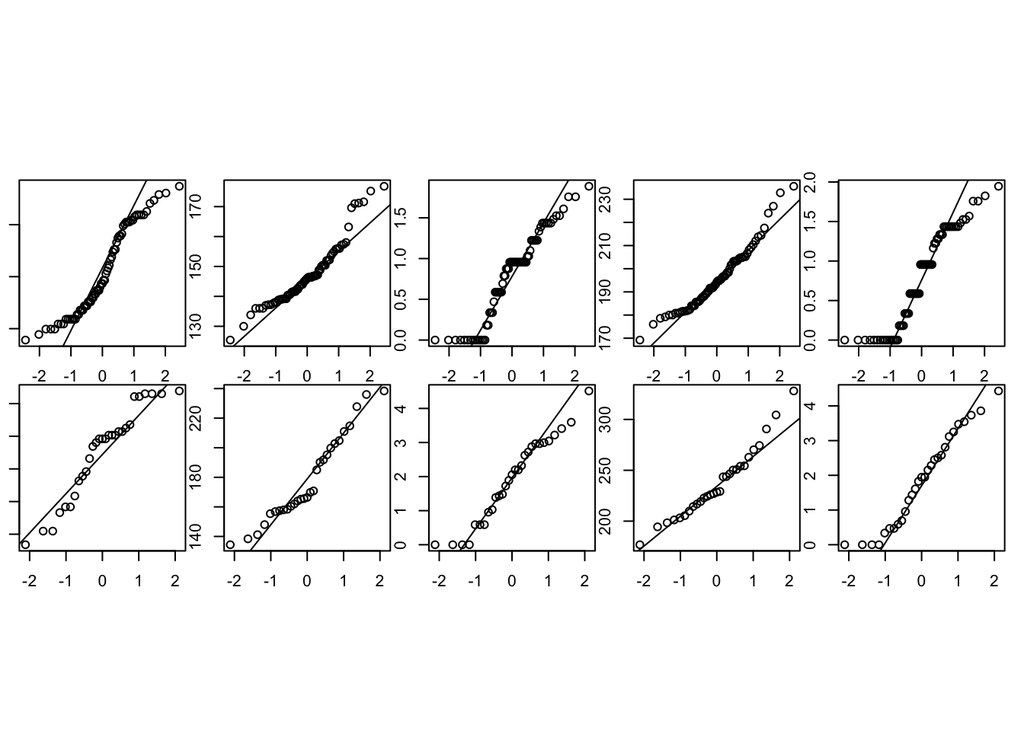

```r
nonmult_trans <- nonmult
mult_trans <- mult
nonmult_trans[,1] <- log(nonmult[,1])
nonmult_trans[,3] <- log(nonmult[,3] + 1)
nonmult_trans[,5] <- log(nonmult[,5] + 1)
mult_trans[,1] <- log(mult[,1])
mult_trans[,3] <- log(mult[,3] + 1)
mult_trans[,5] <- log(mult[,5] + 1)
layout(matrix(1:10, nrow = 2, byrow = TRUE), respect = TRUE)
par(mar=rep.int(1,4))
nonmult.rqs <-  sapply(nonmult_trans, plotqq)
mult.rqs <-  sapply(mult_trans, plotqq)
```

```r
nonmult.rqs
```

```
##        V1        V2        V3        V4        V5
## 0.9651322 0.9613327 0.9656913 0.9757393 0.9536191
```

```r
mult.rqs
```

```
##        V1        V2        V3        V4        V5
## 0.9648514 0.9702901 0.9810525 0.9786859 0.9785249
```

1. As we can see for non-multiple-sclerosis group, only V4 has a qr > 0.97 Thus we remain skeptical about the normality assumption. For multiple-sclerosis group, V1, V2 and V4 all have qrs > 0.97 while qrs of V3 and V5 are less than 0.85.

After logarithm transformation, $ln(x_1), ln(x_3+1), ln(x_5+1)$ appears to be normal. (Add 1 for $x_3, x_5$ since some values are close to 0.)

```r
nonmult_avg <- colMeans(nonmult)
mult_avg <- colMeans(mult)
S1 <- cov(nonmult)
S2 <- cov(mult)
Spool <- ((n1-1) * S1 + (n2-1) * S2) / (n1+n2-2)
d <- nonmult_avg - mult_avg
coefs <- solve(Spool, d) # coefs of discriminant function
coefs
```

```
##          V1          V2          V3          V4          V5
##  0.02340633 -0.03446657  0.21027081 -0.08393327 -0.25345069
```

```r
m <- sum(solve(Spool, d) * (nonmult_avg + mult_avg) / 2)
m # mhat
```

```
## [1] -23.23392
```

As shown above, we allocate x0 to $\pi_1$ if $.023x_1 - .034x_2 + .21x_3 - .08x_4 - .25x_5 + 23.23 \ge 0$ Otherwise, allocate it to $\pi_2$ From this function, we know that first two variables appeart to be less important.

```r
predicted1 <- as.matrix(nonmult) %*% coefs
conf <- matrix(nrow = 2, ncol = 2)
conf[1,1] <- sum(predicted1 >= m)
conf[1,2] <- n1 - conf[1,1]

# mult
predicted2 <- as.matrix(mult) %*% coefs
conf[2,1] <- sum(predicted2 >= m)
conf[2,2] <- n2 - conf[2,1]

# confusion matrix
conf
```

```
##      [,1] [,2]
## [1,]   66    3
## [2,]    7   22
```

```r
APER <- (conf[1,2] + conf[2,1]) / (n1 + n2)
APER
```

```
## [1] 0.1020408
```

The confusion matrix is shown above. APER is about $0.102$